# CS 111 HW

Updated 10 September, 2020

# Grading Guidelines For Homework

Homework solutions will be graded on the following critera:

- Quality and thoughtfulness of presentation. Use of gramatically correct English sentences (when writing English).
- Completion and accuracy of solutions.
- Ingenuity and elegance.
- Relevance to the topic(s) at hand.
- Demonstration of the student’s understanding of the material.
- Creativity, ingenuity, and elegance demonstrated in a student’s ideas and insights.

# HW 3 Due Friday 9/25 by 5pm

**(Under construction, not finished!)**

File Format: turn in a .py script file to NoteBowl. The name should be lastname_firstname_hw3.py. For example:

`lovelace_ada_hw3.py`

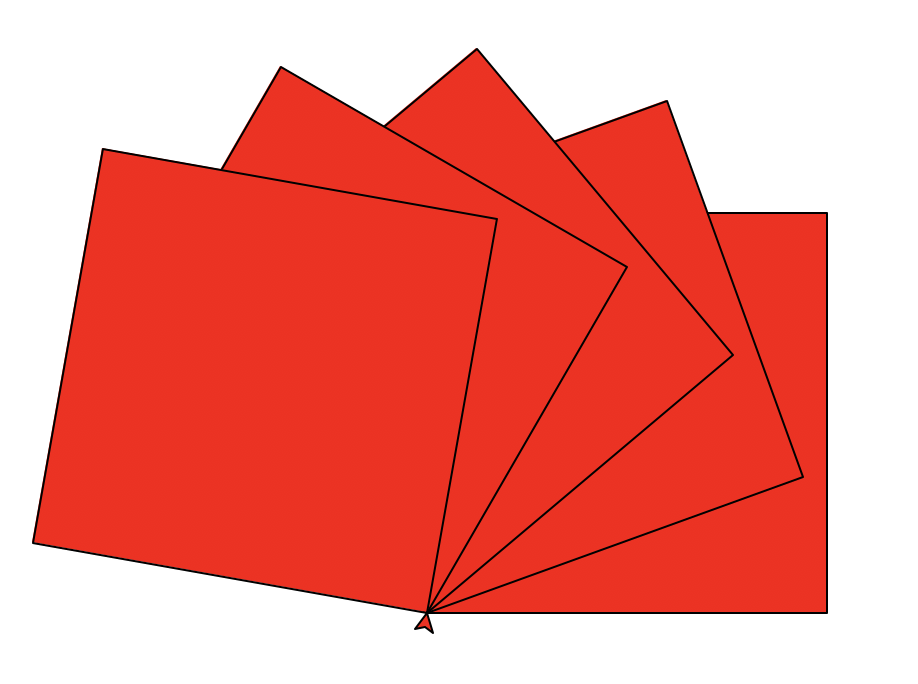

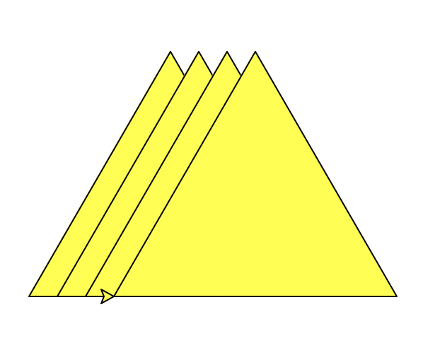

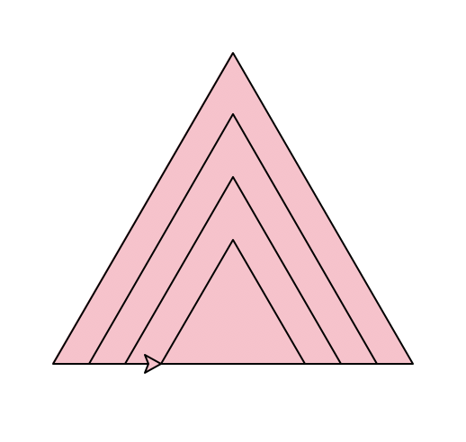

- A `main()` function that controls the logic of the program.

  Your program should use the `input()` function to prompt the user for the following:
  - Triangles or Squares?
  - Side length?
  - Color?
  - Starting coordinates?
  - Spread, Zoom, or Slide? The program should then draw the object requested by the user.

Grading:

- Students can still earn a max of 75/100 if they implement the code for `makeSquare` and `makeTriangle` without errors, according to the specifications. This assumes that students have also implemented a `main()` function as described above.
- If, in addition, students can implement any ONE of the `spread`, `zoom`, or `slide` functions, then they can earn a max of 85/100.
- **For all of the above options**: in order to earn a maximum score, students must implement all functions with correct code, clean style and presentation, docstrings, and **comments**.
- If students add any extra bells and whistles (beyond the full specifications of the assignment), they’ll additionally earn Prof. Miller’s respect. It’s a very valuable commodity. ;D

# HW 2 Due Friday 9/11 by 5pm

File Format: turn in the .ipynb file for your notebook. Name it with this format:

Lastname_Firstname_HW3.ipynb

So, if I was a student, I’d turn in:

Miller_Alice_HW3.ipynb

Problems:

1. 2.2.7
2. 2.2.8
3. 2.3.4
4. In class on Friday Sept 04, we wrote a `for` loop to assign each employee in a list of employees a day of the week to work on.
- Your HW problem is to extend this program in the following way:
  - It should prompt the user (who we’ll call “The Boss”) to enter the list of employees, and the list of days in the week that the business is open. This list can be arbitraily long, depending on what the user inputs. You may assume that all of the names are different. Use the `input()` function. There are many reasonable ways to go about this.
  - It should prompt the user for the list of days that the business is open. You may assume that this list will be some subset of “Mon”, “Tues”, “Wed”, “Thurs”, “Fri”, “Sat”, “Sun”.
- There are two acceptable outputs:
  1. Your program can print out the schedule in the same way we did in Lecture. A correct solution like this will earn a maximum of 92% credit for this problem.
  2. Your program can return a list of lists (one for each day of the work week) that show who works on which day.
     - For example, if the work week consists of Mon, Tue, Wed, Thurs, Fri, and the employee list is Ali, Ben, Charles, Deb, Ellie, Fred, Greg, Helen, Ian, Jack, then the output should be the followign list of lists:

`[['Ali, Fred'], ['Ben', 'Greg'], ['Charles', 'Helen'], ['Deb', 'Ian'], ['Ellie', 'Jack']]`

# HW 1 Due Friday 8/28 by 5pm

File format: Problems should be completed in a Jupyter Labs notebook, exported to html (we’ll talk about this in class). The .html file should be submitted to NoteBowl under the HW 1 assignment.

Each solution should be written in a seperate Markdown cell, showing the problem number with a header (you can make a header by starting the line with “#”).

The first cell of the notebook should have a header for the title of the assignment (CS 111 HW 1), and your name.

The problems for this HW come from the text:

- 1.2.1
- 1.2.2
- 1.2.5
- 1.3.1

All of these problems should be solved in clear, consise English sentences (or lists). No code here.